This vignette demonstrates the new features of our package that are related to checking FDR calibration and model assumptions.

```r
library("magrittr")
library("ggplot2")
```

Here are some good and bad knockoffs to start with.

```r
set.seed(0)
make_bimodal = function(X) rbind(X, X + 10)
X = rnorm(1e4) %>% matrix(ncol = 10)
good_knockoffs = knockoff::create.second_order(X)
X %<>% make_bimodal
good_knockoffs %<>% make_bimodal
bad_knockoffs = knockoff::create.second_order(X)
```

### Simulating Y

Using `calibrate__simulateY`, you can simulate from any P(Y|X) and check any set of knockoffs you generate. It looks conservative on good knockoffs and anticonservative on bad knockoffs.

```r
calibration_check = rlookc::calibrate__simulateY(X, good_knockoffs)
```

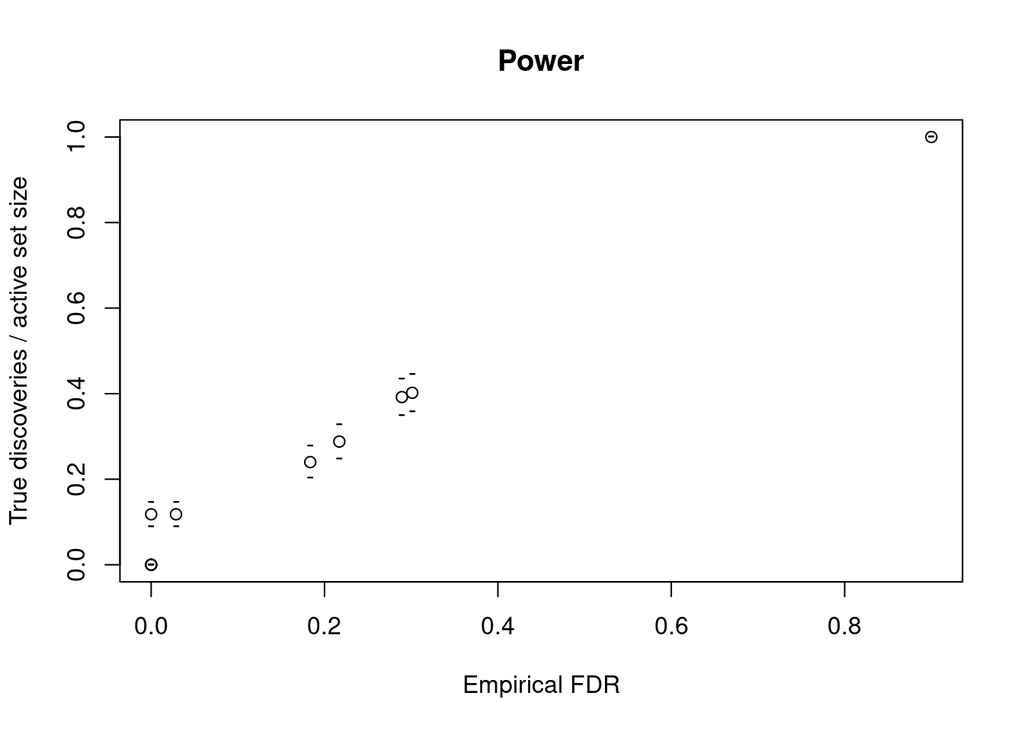

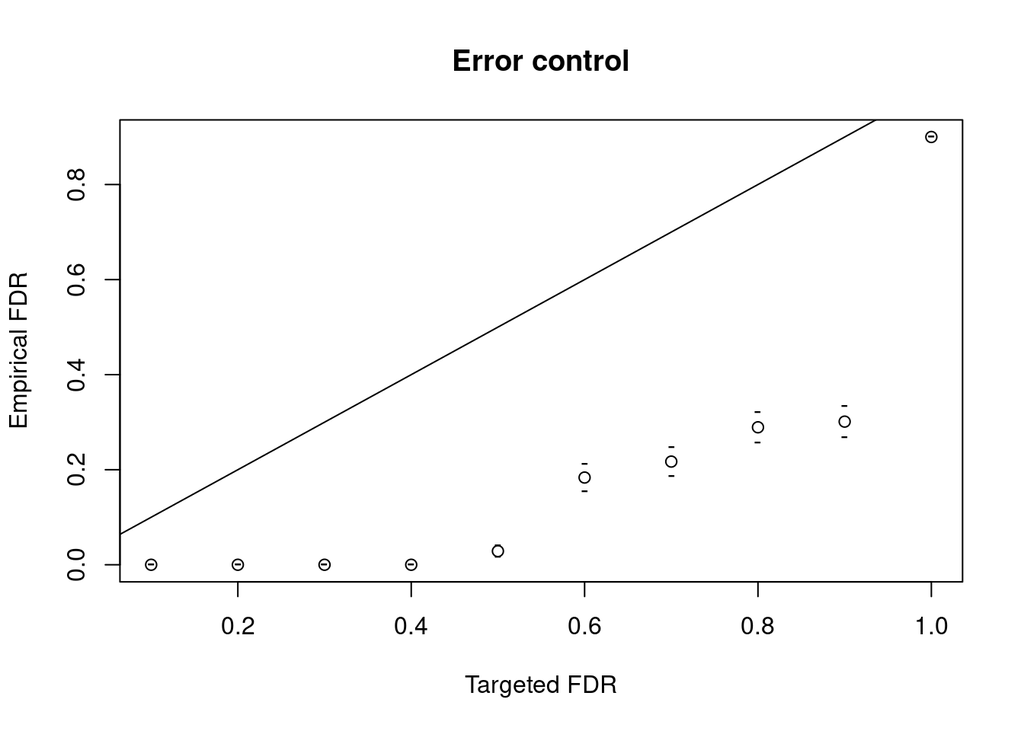

```r
calibration_check2 = rlookc::calibrate__simulateY(X, bad_knockoffs)
```

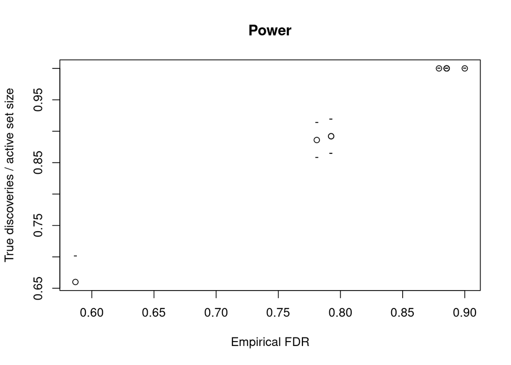

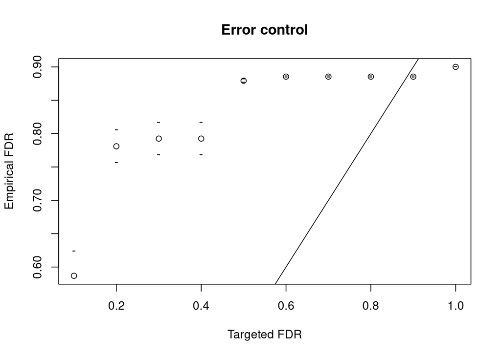

The choice of P(Y|X) has a big effect on the results. When E[Y|X] is linear, this diagnostic has almost no power, as you might expect if you know a lot about fixed-X knockoffs. This is shown in `calibration_check3` below. We try to choose a sensible family. The default is step functions of individual features, indicating when they cross 0. But, you can choose anything and provide it as the FUN argument.

Below, we specify a linear function to demonstrate how the diagnostic loses power.

```r
calibration_check3 = rlookc::calibrate__simulateY(X, bad_knockoffs, FUN = function(x) 2*x)
```

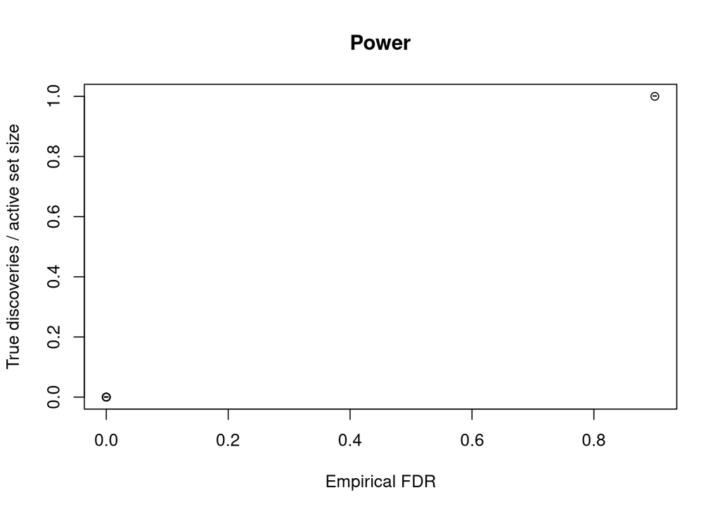

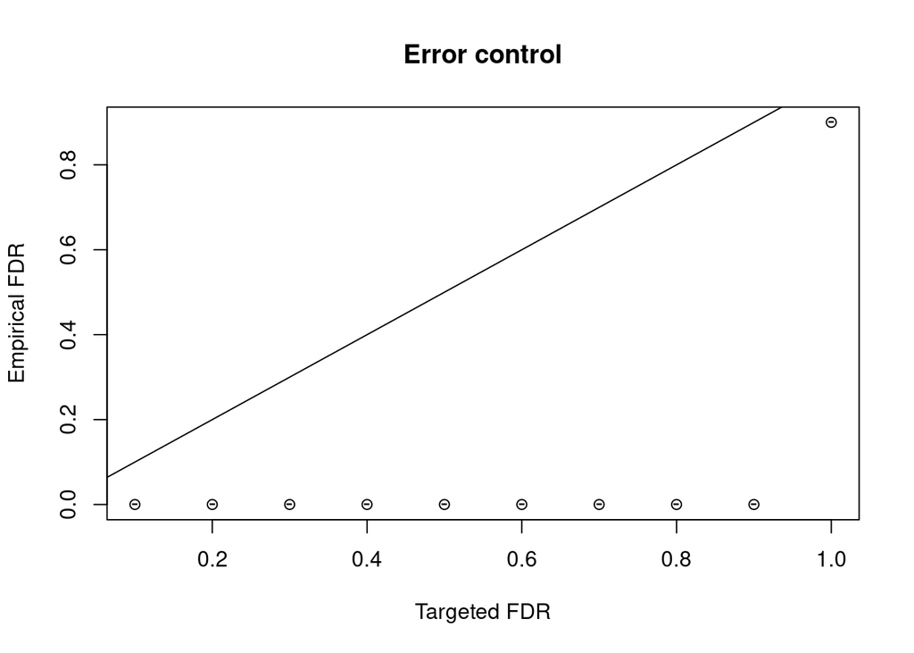

You can see the difference more easily if we put all the calibration plots on the same window.

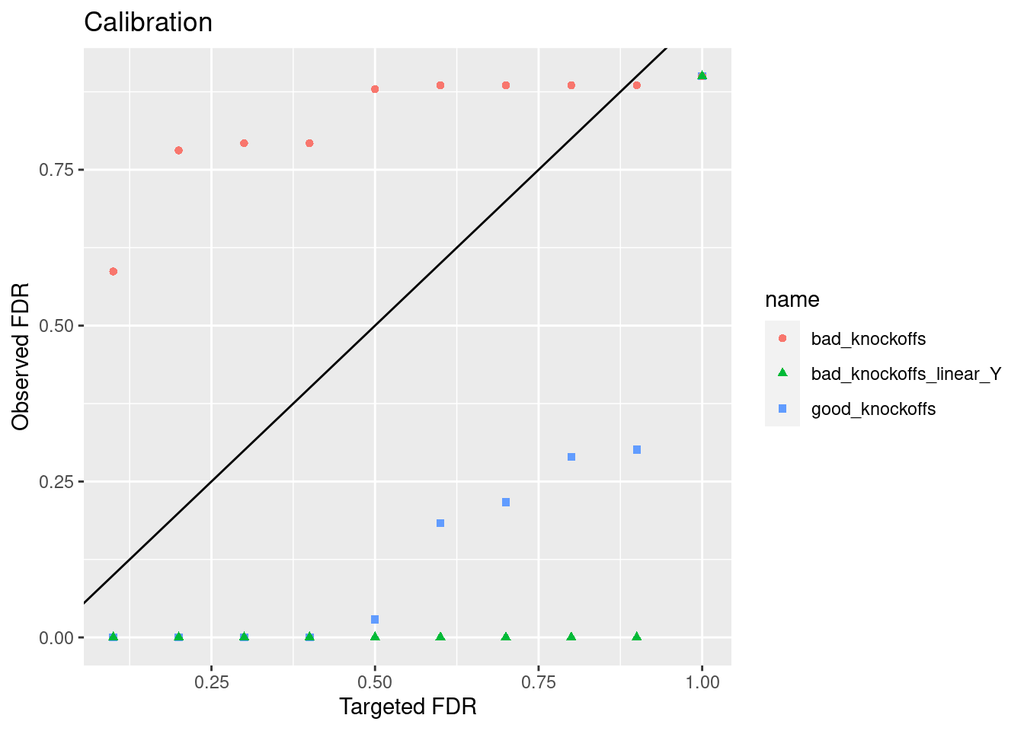

```r
data.frame( targeted_fdr = calibration_check$calibration$targeted_fdrs,
            good_knockoffs = calibration_check$calibration$fdr %>% colMeans,
            bad_knockoffs = calibration_check2$calibration$fdr %>% colMeans,
            bad_knockoffs_linear_Y = calibration_check3$calibration$fdr %>% colMeans) %>%
  tidyr::pivot_longer(cols = 2:4) %>%
  ggplot() +
  geom_point(aes(x = targeted_fdr, y = value, color = name, shape = name)) +
  ggtitle("Calibration") +
  geom_abline(a = 0, b = 1)+
  xlab ("Targeted FDR") +
  ylab( "Observed FDR")
```

You can use `calibrate__chooseDiverseY` and `calibrate__findWorstY` to try to search more thoroughly for a worst-case P(Y|X). `calibrate__findWorstY` will split the data, searching for the worst P(Y|X) in one half and checking calibration in the other half.

```r
collection_of_y = rlookc::calibrate__chooseDiverseY(X, n_quantiles = 5)
worst_y = rlookc::calibrate__findWorstY(X, bad_knockoffs,
                                       y = collection_of_y$y,
                                       ground_truth = collection_of_y$ground_truth)
```

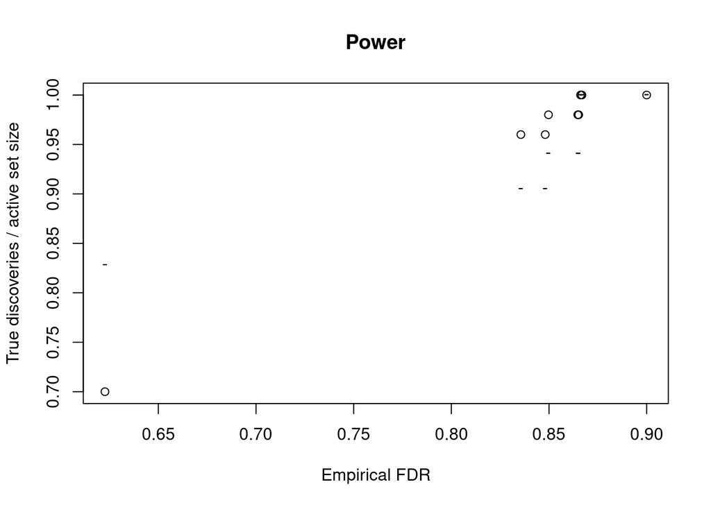

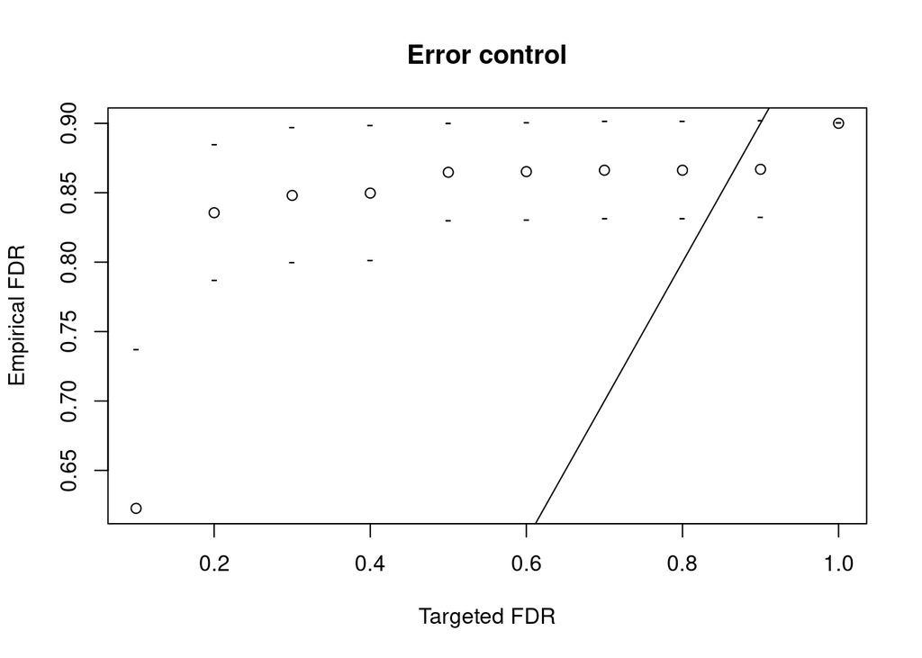

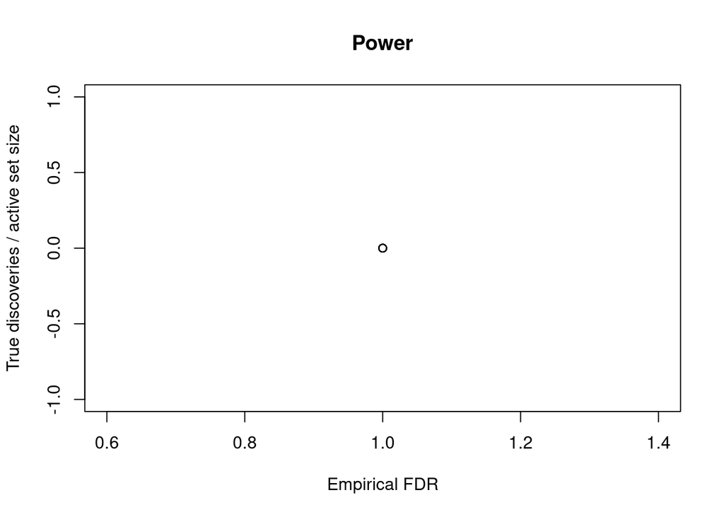

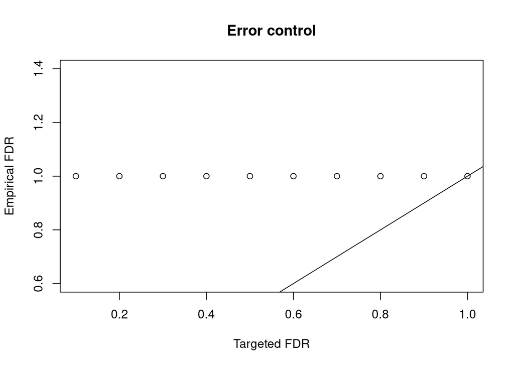

Once these have run, you can compare the worst-case Y to another Y or otherwise try to determine informative properties of the worst-case Y.

```r
collection_of_y$ground_truth[[worst_y$worst_y]]
```

```
## [1] 4
```

```r
cor( X, collection_of_y$y[[worst_y$worst_y]])
```

```
##            [,1]
##  [1,] 0.9806746
##  [2,] 0.9793088
##  [3,] 0.9822847
##  [4,] 0.9817105
##  [5,] 0.9799441
##  [6,] 0.9799190
##  [7,] 0.9816341
##  [8,] 0.9812053
##  [9,] 0.9803461
## [10,] 0.9804713
```

```r
cor( bad_knockoffs, collection_of_y$y[[worst_y$worst_y]])
```

```
##            [,1]
##  [1,] 0.9726156
##  [2,] 0.9730999
##  [3,] 0.9755866
##  [4,] 0.9758989
##  [5,] 0.9725183
##  [6,] 0.9736956
##  [7,] 0.9729186
##  [8,] 0.9727340
##  [9,] 0.9737045
## [10,] 0.9725155
```

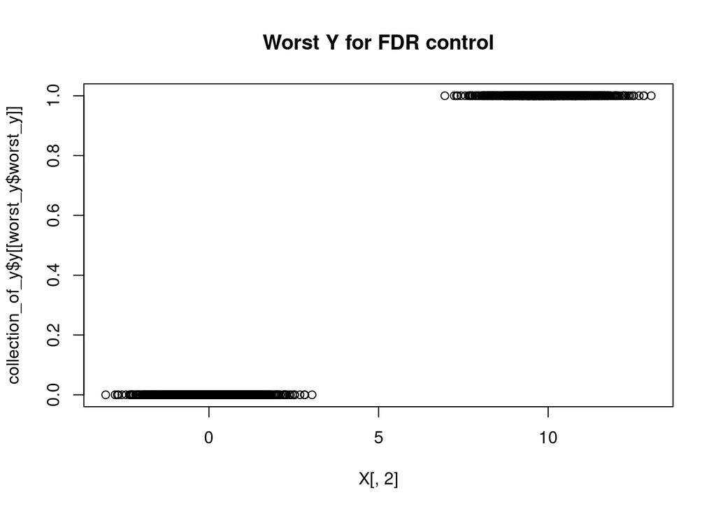

```r
plot(X[,2], collection_of_y$y[[worst_y$worst_y]], main = "Worst Y for FDR control")
```

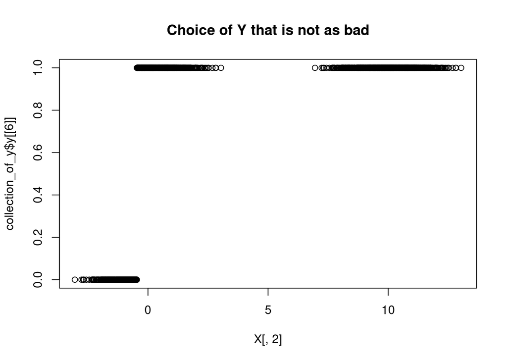

```r
plot(X[,2], collection_of_y$y[[6]], main = "Choice of Y that is not as bad")
```

### Testing exchangeability

Using `calibrate__KNNTest`, you can check exchangeability for any set of knockoffs you generate. This test is less customizeable than the above but we find it is often much more sensitive. It is sensitive to any deviation from exchangeability without the need for a careful choice of P(Y|X).

```r
set.seed(0)
X = rnorm(1e4) %>% matrix(ncol = 10)
A = rnorm(1e2) %>% matrix(ncol = 10) %>% add(1) # to induce known correlation across variables
X = X %*% A
good_knockoffs = knockoff::create.gaussian(X, mu = 0, Sigma = t(A) %*% A)
bad_knockoffs = apply(X, 2, sample)
rlookc::calibrate__KNNTest(X, good_knockoffs)[2:3]
```

```
## $prop_not_swapped
## [1] 0.5022
##
## $p_value
## [1] 0.2668874
```

```r
rlookc::calibrate__KNNTest(X, bad_knockoffs)[2:3]
```

```
## $prop_not_swapped
## [1] 0.75715
##
## $p_value
## [1] 0
```

You can sometimes pinpoint outliers by choosing specific data points that have too few swapped neighbors.

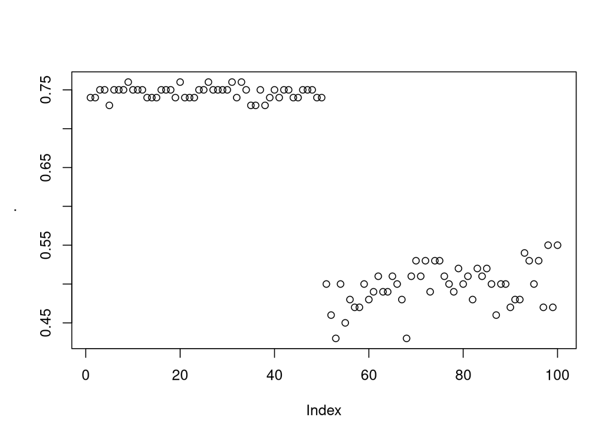

```r
X[1:50,1:5] = -100
rlookc::calibrate__KNNTest(X, good_knockoffs, n_neighbors = 100)$prop_not_swapped_per_observation %>%
  head(100) %>%
  plot
```

The conservative action to take is to use exact dupes of the data for any observations you think don’t fit the model for P(X). This will restore exchangeability, possibly with a loss of power.

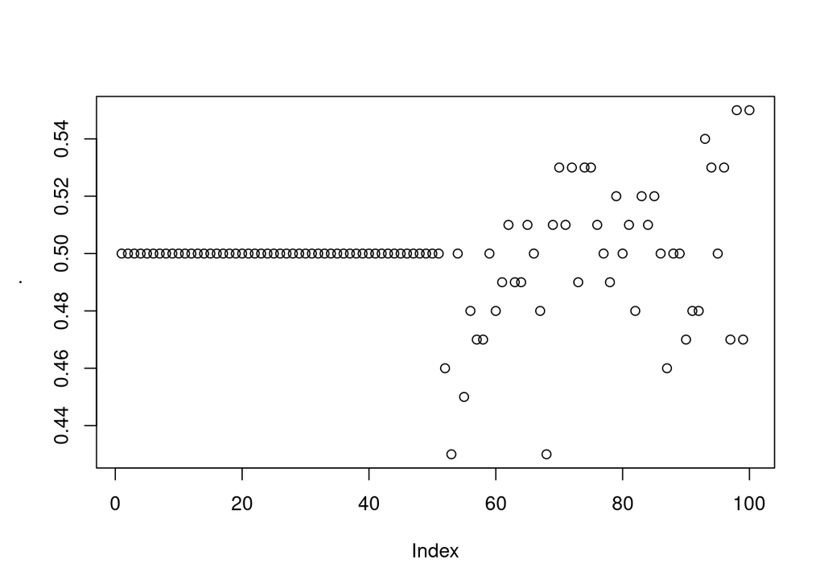

```r
good_knockoffs_outlier_dupe = good_knockoffs
good_knockoffs_outlier_dupe[1:50,] = X[1:50,]
rlookc::calibrate__KNNTest(X, good_knockoffs_outlier_dupe, n_neighbors = 100)$prop_not_swapped_per_observation %>%
  head(100) %>%
  plot
```